# Boston Metropolitan Area Trends

Kubi Jacisin

## Boston Metropolitan Area Trends

This data set was compiled from census tract information collected from the greater Boston and surrounding areas which is here designated as the core based statistical area (CBSA) of all the counties within the Boston, Cambridge, Newton, and MA-NH areas. This exploratory data analysis sought to analyze various interesting trends among unrelated variables to get deeper insight to who and what kinds of people live in and around this area. The first interesting variable that was observed was the percentage of people who choose “green” methods of transportation to get to work and back every day. The variables for individuals who took either public transportation, biked, or walked to work were compiled together and visually displayed on the map below. Percentages are divided into four different groups from 0%-21.6%, 21.6%-43.1%, 43.1%-64.7%, and 64.7%-86.4%. The first important observation to be made is that with the exception of one or two points it seems that the vast majority of people who live in this area work in or within a close proximity to the city of Boston. However, there is a clear pattern that virtually everyone who lives outside the city does not use green form of transportation to get into work. The red dots mean that at the very least 79% of people who live in those areas use cars to get to work (The amount of people who work from home is statistically insignificant and has been omitted from this report).This could be due to the fact that Boston’s small and poorly run subway system, known as the T, is the oldest subway system in North America and does not reach very far outside the immediate confines of the city. As the vicinity to the center of the city get closer there is a clear observable trend. At the heart of the city close to 50% and higher of people use green methods to get to work. Boston is an old city and unlike NYC and Chicago is not built on a grid system making navigation through the city challenging. This combined with a lack of parking spaces could contribute to city dwellers owning less cars and therefore having to rely on other means of transportation to get to work.

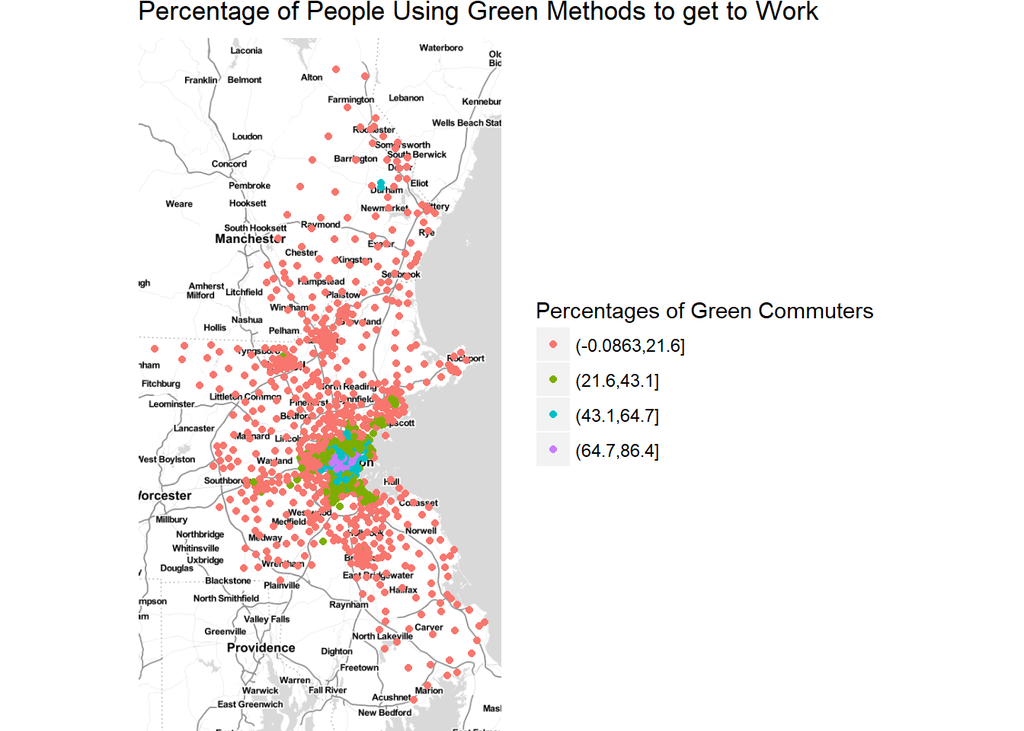

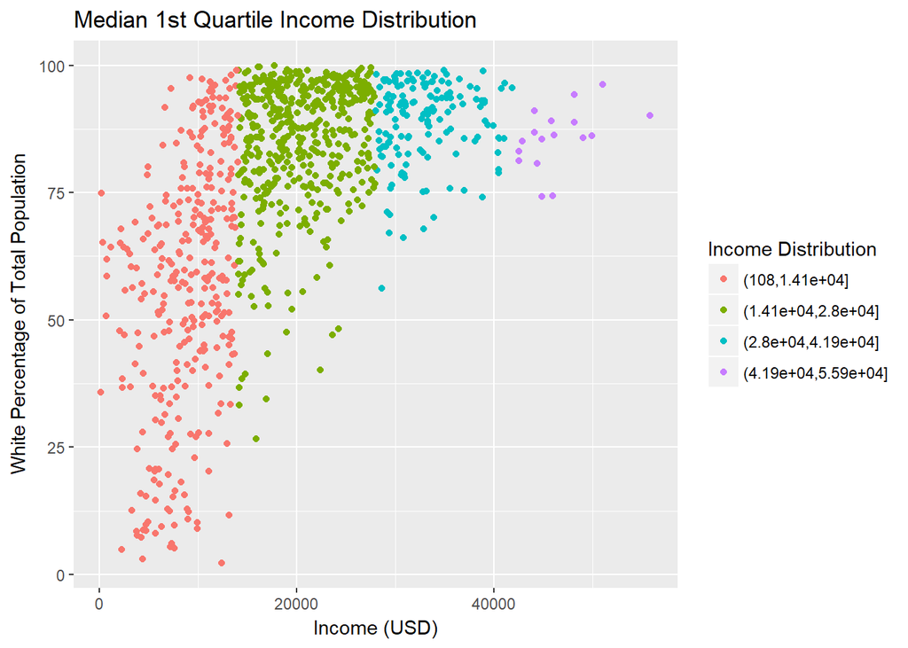

While creating numerous graphs I came across a visualization that I found particularly interesting not because of a certain pattern, but rather because of a lack of one. Observing median rent distribution by population size I found that there was no discernable difference in the median amount of rent due per month based on population size. To this point in my life I assumed without much thought that area with a greater and denser population would have rents marginally higher than smaller and less densely populated areas. The more people in an area the more competition for a limited number of spaces to live and the more landlords can charge renters to live there. However, the graph below shows an even distribution of median rent between $1,000 - $1,500 for populations ranging from just over a thousand people to as much as eight thousand residents. This lack of pattern could be explained by the fact that even though populations are known for areas, the population densities as well as total land area are not known. Potentially some areas that have populations of eight thousand also have a huge land area and therefore no overcrowding results.

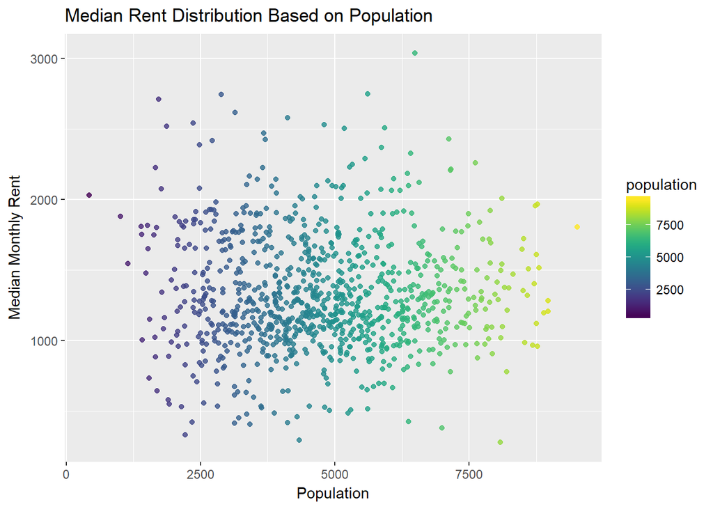

## References

Tremont Street Subway: A Century of Public Service, by Bradley H. Clarke and O.R. Cummings (Boston Street Railway Association, 1997).